# Compléments sur R - TD 3

Traitement des données

INTECHMER - CT2 GEM/PVRM

## Projet

Comme vous avez pu le remarquer, entre deux sessions de R, un certain nombre d’éléments sont *oubliés*, en particulier le répertoire de travail. Pour palier, à ce problème, il existe, dans **R Studio**, la notion de **Projet** qui permet de garder en mémoire la configuration plus globale de R.

Pour créer un nouveau projet, vous devez suivre les étapes suivantes :

1. Cliquer sur *File*
2. Choisir *New Project*
- Veillez à bien indiquer que vous souhaitez sauvegarder votre travail
3. Indiquer si c’est dans un nouveau répertoire ou dans un répertoire existant (puis le choisir)
4. Choisir le type de projet
- Nous, ce sera toujours *New project*
5. Indiquer le nom du projet (et donc du répertoire)
- par exemple `mon_projet`
5. Cliquer sur *Create project*

> Une nouvelle instance de R Studio est ouverte, avec une nouvelle session de R. Un fichier `mon_projet.Rproj` est maintenant créé dans le répertoire `mon_projet/`.

Vous pouvez maintenant faire les modifications que vous le souhaitez (ouvrir certains fichiers, choisir un répertoire de travail spécifique - souvent celui du projet, …). Tant que le projet sera sauvegardé régulièrement, la session **R Studio** sera la même quand vous relancerez le logiciel en ouvrant le fichier

## Document `R markdown`

Un document `R markdown` (généralement enregistré avec l’extension `.rmd` ou `.Rmd`) permet d’une part d’utiliser la syntaxe [`markdown`](https://daringfireball.net/projects/markdown/) pour écrire du texte, mais aussi d’inclure des commandes `R` directement dans le document. Ainsi, un seul document contient le code et le commentaire, ce qui est un atout non négligeable pour des rapports ou présentations devant être mises à jour ou refaits régulièrement.

Il est possible d’inclure les commandes `R` soit dans un bloc de code, appelé *chunk* dans **R Studio**, ou en ligne, appelé *inline chunk*.

Pour créer un document `R markdown` dans **R Studio**, vous pouvez cliquer sur l’icône avec un plus, puis sur *R markdown…*. Vous devez voir apparaître une interface vous demandant de choisir entre un document, une présentation, une application *Shiny* ou de choisir un *template* prédéfini. Nous allons rester sur le *document* pour le moment. De plus, vous pouvez indiquer le titre et l’auteur, ainsi que choisir le format de sortie (HTML, PDF ou Word). Nous allons garder HTML pour le moment.

### En-tête

Lors de la création d’un nouveau document `R markdown`, vous devez voir apparaître en début de document une partie d’en-tête, comme ci-dessous, au format `YAML`.

```
---
title: "Untitled"
author: "FX Jollois"
date: "04/03/2025"
output: html_document
---
```

Dans cette en-tête, nous pouvons donc définir le titre, éventuellement un sous-titre (avec `subtitle:`), le ou les auteurs, la date et des options de sortie. Pour le moment, nous allons garder la sortie au format HTML. Pour passer au format `PDF`, il faut écrire `pdf_document` dans `output` (ainsi qu’avoir $\LaTeX$ installé sur sa machine). Pour créer un document de type Word, il faut choisir `word_document` pour `output`.

Il y a d’autres possibilités de sortie, ainsi que la possibilité d’ajouter d’autres paramètres de sortie, que nous ne verrons pas ici.

### *Chunk*

Un *chunk* sera donc un bloc de commande `R` (ou autre langage possible) qui sera exécuté par **R Studio**. Pour cela, il faut indiquer sur la première ligne le langage utilisé. Pour `R`, voici donc un exemple simple

````
```{r}
# code R
summary(iris)
```
````

Dans le document sera donc intégré à la fois le code, ainsi que le résultat de son exécution. L’exemple donnera donc

```r
# code R
summary(iris)
```

```
##   Sepal.Length    Sepal.Width     Petal.Length    Petal.Width
##  Min.   :4.300   Min.   :2.000   Min.   :1.000   Min.   :0.100
##  1st Qu.:5.100   1st Qu.:2.800   1st Qu.:1.600   1st Qu.:0.300
##  Median :5.800   Median :3.000   Median :4.350   Median :1.300
##  Mean   :5.843   Mean   :3.057   Mean   :3.758   Mean   :1.199
##  3rd Qu.:6.400   3rd Qu.:3.300   3rd Qu.:5.100   3rd Qu.:1.800
##  Max.   :7.900   Max.   :4.400   Max.   :6.900   Max.   :2.500
##        Species
##  setosa    :50
##  versicolor:50
##  virginica :50
##
##
##
```

Il est possible de nommer le *chunk* en lui donnant un label (sans espace, sans accent) après `r` dans les `{}`. Ceci est intéressant surtout dans l’étape de développement, car si une erreur arrive lors de l’exécution, il sera plus facile de retrouver dans quel *chunk* est l’erreur (indiqué lors de l’affichage de l’erreur).

De plus, il est possible de mettre des options dans le *chunk*, toujours dans les `{}`, après une `","`. Voici quelques options classiques et utiles (avec leur valeur par défaut indiquée, si elle existe) :

- `include = TRUE` : si `FALSE`, le code est exécuté mais il n’est pas inclus dans le document (ni le code, ni son résultat)
- `echo = TRUE` : si `FALSE`, le code n’est pas affiché mais bien exécuté
- `eval = TRUE` : si `FALSE`, le code est affiché mais n’est pas exécuté
- `results = 'markup'` : permet de définir comment le résultat est affiché (intéressant parfois)
- `fig.cap` : titre du graphique produit

Il est possible de mettre plusieurs options, toutes séparées par des `","`.

#### Quelques exemples

Dans la suite, voici quelques exemples de *chunks* avec options. Regardez le source pour mieux comprendre le fonctionnement.

Tout d’abord, on importe les données `Iris.txt`, mais ce genre de code n’est souvent pas à inclure, dans le sens où l’on ne veut ni l’afficher, ni voir de résultat.

Ensuite, la librairie `knitr` contient une fonction `kable()` permettant d’afficher un `data.frame` au format `markdown`. Cela permet d’avoir un résultat plus lisible qu’une sortie de console `R` classique.

```r
knitr::kable(head(iris, 10))
```

| Sepal Length | Sepal Width | Petal Length | Petal Width | Species |
| --- | --- | --- | --- | --- |
| 5.1 | 3.5 | 1.4 | 0.2 | setosa |
| 4.9 | 3.0 | 1.4 | 0.2 | setosa |
| 4.7 | 3.2 | 1.3 | 0.2 | setosa |
| 4.6 | 3.1 | 1.5 | 0.2 | setosa |
| 5.0 | 3.6 | 1.4 | 0.2 | setosa |
| 5.4 | 3.9 | 1.7 | 0.4 | setosa |
| 4.6 | 3.4 | 1.4 | 0.3 | setosa |
| 5.0 | 3.4 | 1.5 | 0.2 | setosa |
| 4.4 | 2.9 | 1.4 | 0.2 | setosa |
| 4.9 | 3.1 | 1.5 | 0.1 | setosa |

Enfin, on peut vouloir faire un graphique, ce qui pourrait donner ce qui suit. Pour ce genre de présentation, nous pouvons décider de ne pas afficher le code permettant de les obtenir.

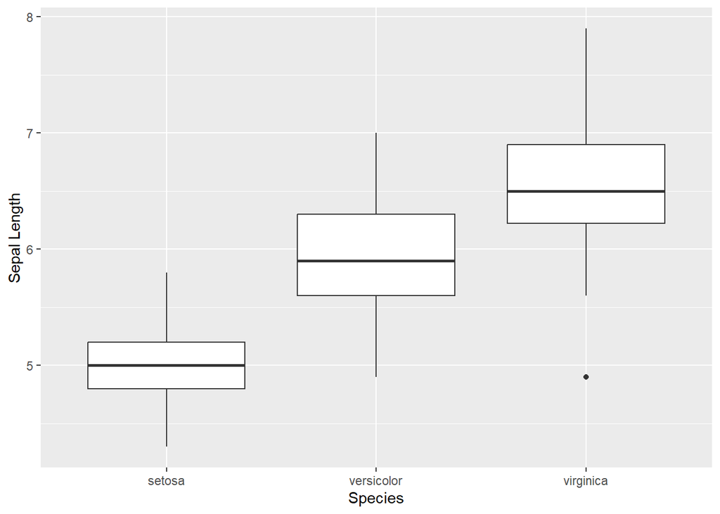

Répartition de la longueur de sépale selon l’espèces des individus

### *Inline chunk*

On peut faire des *chunks* en ligne en encadrant le code avec des `` ` `` et en commencant le code par un `r`. Par exemple, on peut dire que dans le jeu de données `iris` sont présentés 150 individus et 5 variables.

### Paramètres globaux des *chunks*

Il est possible de déterminer des paramètres globaux pour tous les blocs *chunks* du document (sauf paramètres locaux précisés). Ceci doit se faire comme suit, avec la fonction `set()` de l’objet `opts_chunk` de la librairie `knitr`. Il est par exemple possible de définir `echo=FALSE` pour n’avoir aucun code apparaissant dans le document.

```
knitr::opts_chunk$set(...)
```

## Fichiers `.RData`

Plutôt que de devoir importer plusieurs fois des données, il est possible d’utiliser le format de données `.RData`, qui permet de sauvegarder tout ou partie de l’environnement de travail. Pour cela, nous allons utiliser les fonctions `save()` et `save.image()` pour sauvegarder, et la fonction `load()` pour charger les variables sauvegardées.

### Sauvegarde de variable(s)

En premier lieu, il est possible de sauvegarder uniquement une variable créée dans un fichier `.RData`. Ci-dessous, nous créons l’objet `a`, qui est une chaîne simple, puis nous la sauvegardons dans le fichier `a.RData`. Enfin, nous la supprimons (et l’affichons pour bien voir qu’elle n’existe plus).

```r
a = "test de RData"
print(a)
```

```
## [1] "test de RData"
```

```r
save(a, file = "a.RData")
rm(a)
print(a)
```

```
## Error in eval(expr, envir, enclos): objet 'a' introuvable
```

L’intérêt est donc que la variable `a` est dans le fichier `.RData`, qu’il est possible de charger dans `R` comme suit.

```r
load("a.RData")
print(a)
```

```
## [1] "test de RData"
```

Pour sauvegarder plusieurs variables, il faut juste les lister dans la fonction `save()`.

```r
b = "deuxième test de RData"
c = 123456789
save(b, c, file = "bc.RData")
rm(b, c)
print(b, c)
```

```
## Error in eval(expr, envir, enclos): objet 'b' introuvable
```

Et on les charge de la même façon.

```r
load("bc.RData")
print(b)
```

```
## [1] "deuxième test de RData"
```

```r
print(c)
```

```
## [1] 123456789
```

### Sauvegarde de l’environnement

Quand on lance la fonction `ls()`, on liste l’ensemble des objets créés dans l’environnement de travail. La fonction `save.image()` va tous les sauvegarder dans un même fichier `.RData`.

```r
ls()
```

```
## [1] "a"    "b"    "c"    "iris"
```

```r
save.image("env.RData")
```

Ensuite, nous allons nettoyer l’environnement de travail, en supprimant tous les objets (1ère ligne ci-dessous). Ainsi, en listant les variables avec `ls()`, on s’aperçoit qu’il n’y a plus rien.

```r
rm(list = ls()) # Pour tout supprimer de l'environnement
ls()
```

```
## character(0)
```

Enfin, toujours avec la fonction `load()`, on charge les variables présentes dans le fichier, qu’on retrouve bien en faisant un `ls()`.

```r
load("env.RData")
ls()
```

```
## [1] "a"    "b"    "c"    "iris"
```

## A faire

Dans votre document, penser à nommer chaque chunk différemment. Et n’hésiter pas à commenter le document pour le rendre plus conforme à ce qu’on pourrait vouloir produire comme document.

Vous trouverez sur le site [rmarkdown](https://daringfireball.net/projects/markdown/) beaucoup d’informations et de compléments sur cette librairie. Beaucoup sont résumées dans ce [document](https://utstat.utoronto.ca/reid/sta2201s/rmarkdown-reference.pdf) et [celui-ci](https://posit.co/wp-content/uploads/2022/10/rmarkdown-1.pdf).

Nous allons travailler sur les données `varespec` et `varechem` présente dans le package `vegan`. Quelques informations sont disponibles sur [cette page](https://vegandevs.github.io/vegan/reference/varechem.html). Pour les charger dans R, vous devez exécuter les commandes suivantes :

```r
data(varechem)
data(varespec)
```

1. Créer un nouveau document `R markdown`, intitulé `"TP"`, avec votre nom comme auteur
2. Sauvegarder ce document sous le nom `"TP.Rmd"`
3. Cliquer sur le bouton *knit* pour voir le résultat de l’exemple fourni
4. Supprimer le contenu du document, en gardant uniquement l’en-tête
5. Paramétrer l’ensemble des chunks pour ne pas voir apparaître le code des *chunks* dans le résultat
6. Créer 4 titres de niveau 2, avec le contenu suivant
   1. **Données** :
      - écrire un texte introductif précisant (en ligne) le nombre de lignes et de colonnes du jeu de données `varechem`, et incluant un lien vers la page de présentation
      - afficher proprement l’ensemble du jeu de données
   2. **`Baresoil`**
      - Histogramme de la variable `Baresoil`
      - Boîte à moustache de la même variable
   3. **`Fe`** :
      - créer une nouvelle variable `Fe_bin` dans le jeu de données `varechem` prenant comme valeur `"high"` pour `Fe > 50` et `"low"` sinon, en affichant le code pour la créer
      - afficher un tableau à deux colonnes :
        - `"Fe"` avec les deux modalités de `Fe_bin`
        - `"Effectif"` avec l’effectif pour chaque transmission
      - afficher le diagramme circulaire de la répartition des voitures en fonction de leur transmission avec les paramètres suivants :
        - un titre de figure indiquant ce qui est représenté (cf `fig.cap`)
        - centrage dans le document (cf `fig.align`)
        - largeur et hauteur de `2.5`(cf `fig.width` et `fig.height`)
        - la couleur `"orange"` pour `"high"` et `"blue"` pour `"low"`
7. Maintenant,
   1. Créer un fichier texte `script.R` dans lequel vous allez placer tout votre code d’importation des données, de manipulations de celles-ci et de création des graphiques
   2. Stocker les graphiques dans des variables lors de la création
   3. Créer un fichier `RData` contenant l’ensemble des éléments utiles pour la création de votre fichier `html`
   4. Utiliser ce fichier `RData` dans votre fichier `Rmd`